# INFO201 - PS5

2023-02-17

**1 Load and check data (5pt)**

1. (1pt) For solving the problems, and answering the questions, create a new rmarkdown docu-ment with an appropriate title.
2. (2pt) Load data. How many rows/columns do we have?

```r
library(dplyr)
```

```r
library(ggplot2)

df <- read.delim("gapminder.csv")

nrow(df)
```

```
## [1] 13055
```

```r
ncol(df)
```

```
## [1] 25
```

3. (2pt) Print a small sample of data. Does it look OK?

```r
df %>% sample_n(5)
```

```
##   iso3         name iso2   region                      sub.region
## 1  MAR      Morocco   MA   Africa                 Northern Africa
## 2  TUN      Tunisia   TN   Africa                 Northern Africa
## 3  SMR   San Marino   SM   Europe                 Southern Europe
## 4  TKM Turkmenistan   TM     Asia                    Central Asia
## 5  PRY     Paraguay   PY Americas Latin America and the Caribbean
##   intermediate.region time totalPopulation fertilityRate lifeExpectancy
## 1                     1980        19990012         5.685         57.560
## 2                     1972         5291338         6.465         53.452
## 3                     2000           27462            NA             NA
## 4                     2009         5007954         2.769         66.355
## 5       South America 2017         6867062         2.453         73.992
##   childMortality youthFemaleLiteracy youthMaleLiteracy adultLiteracy    GDP_PC
## 1          132.3                  NA                NA            NA  1351.206
## 2          160.5                  NA                NA            NA  1561.460
## 3            6.0                  NA                NA            NA 61992.940
## 4           43.8                  NA                NA            NA  4129.540
## 5           20.8                  NA                NA            NA  5272.361
##   accessElectricity agriculturalLand agricultureTractors cerealProduction
## 1                NA           289300               24684          4514720
## 2                NA            89470               23500          1231300
## 3         100.00000               10                  NA               NA
## 4          99.59204           342050                  NA          1447360
## 5          99.30000           217380                  NA          7207780
##   fertilizerHa       co2 greenhouseGases   co2_PC pm2.5_35 battleDeaths
## 1     27.44608 15944.116       29395.295  0.79760       NA           NA
## 2     11.14551  4737.764        9434.597  0.89538       NA           NA
## 3           NA        NA              NA       NA       NA           NA
## 4           NA 50340.576       80016.140 10.05212       NA           NA
## 5    116.79694        NA              NA       NA        0           NA
```

**2 Descriptive statistics (15pt)**

1. (3pt) How many countries are there in the dataset? Analyze all three: iso3, iso2 and name.

```r
n_distinct(df$name)
```

```
## [1] 250
```

```r
n_distinct(df$iso2)
```

```
## [1] 249
```

```r
n_distinct(df$iso3)
```

```
## [1] 253
```

2. If you did this correctly, you saw that there are more names than iso-2 codes, and there are even more iso3 -codes. What is going on? Can you find it out?
1. (5pt) Find how many names are there for each iso-2 code. Are there any iso-2 codes that correspond to more than one name? What are these countries?

```r
df %>% group_by(iso2) %>% summarise(n = n_distinct(name)) %>% filter(n>1)
```

```
## # A tibble: 1 × 2
##   iso2      n
##   <chr> <int>
## 1 ""        2
```

```r
df %>% filter(iso2 =="" & name !="Namibia") %>% group_by(name) %>% summarise()
```

```
## # A tibble: 1 × 1
##   name
##   <chr>
## 1 ""
```

There is no iso-2 codes correspond to more than one name. In fact, there are two countries have blank iso-2 codes. One of them is Namibia, but that is because Namibia’s iso-2 codes is ‘NA’. There is one country has blank name and blank iso-2 code.

2. (5pt) Now repeat the same for name and iso3-code. Are there country names that have more than one iso3-code? What are these countries? Hint: two of these entitites are CHANISL and NLD CURACAO.

```r
df %>% filter(name == "" & name != "NA") %>% group_by(iso3) %>% summarise(names = unique(name))
```

```
## # A tibble: 4 × 2
##   iso3        names
##   <chr>       <chr>
## 1 CHANISL     ""
## 2 GBM         ""
## 3 KOS         ""
## 4 NLD_CURACAO ""
```

There are four iso3-codes correspond to blank country names, they are CHANISL, GBM, KOS, and NLD_CURACAO.

3. (2pt) What is the minimum and maximum year in these data?

```r
min(df$time,na.rm=TRUE)
```

```
## [1] 1960
```

```r
max(df$time,na.rm=TRUE)
```

```
## [1] 2019
```

The minimum year is 1960 and the maximum year is 2019.

**3 CO2 emissions (30pt)**

Next, let’s analyze CO2 emissions. 1. (2pt) How many missing co2 emissions are there for each year? Analyze both missing CO2 and co2_PC. Which years have most missing data?

```r
df_missingco2 <- df %>% group_by(time) %>% summarise(n_missingc02 = sum(is.na(co2)),n_missingc02pc = sum(is.na(co2_PC)))

df_missingco2 %>% arrange(desc(n_missingc02))
```

```
## # A tibble: 61 × 3
##     time n_missingc02 n_missingc02pc
##    <int>        <int>          <int>
##  1  2017          217            217
##  2  2018          217            217
##  3  2019          217            217
##  4  1960           60             60
##  5  1961           60             60
##  6  1962           58             58
##  7  1963           57             57
##  8  1964           51             51
##  9  1965           51             51
## 10  1966           51             51
## # … with 51 more rows
```

It seems that 2017, 2018, and 2019 have the most missing data, they all have 217 missing data.

2. (5pt) Make a plot of total CO2 emissions over time for the U.S, China, and India. Add a few more countries of your choice. Explain what do you see.

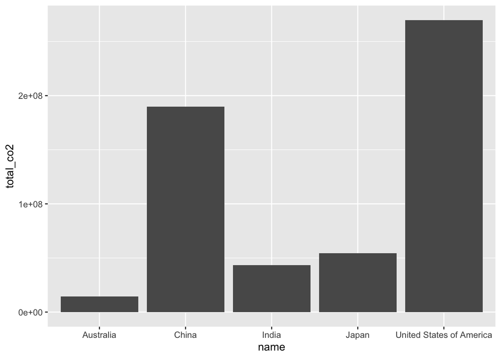

```r
co2_plot <- df %>% group_by(name) %>% summarise(total_co2 = sum(co2,na.rm=TRUE)) %>% filter(name == "United States of America" | name =="China" | name == "India" | name == "Japan" | name == "Australia")

ggplot(data = co2_plot, aes(y = total_co2, x = name ))+ geom_bar(stat="identity")
```

US has the most total CO2 emissions over time, China has the second most, then is Japan, India, and Australia. US and China’s total CO2 emissions are significantly higher than the other three countries’s.

3. (5pt) Now let’s analyze the CO2 emissions per capita (co2_PC ). Make a similar plot of the same countries. What does this figure suggest?

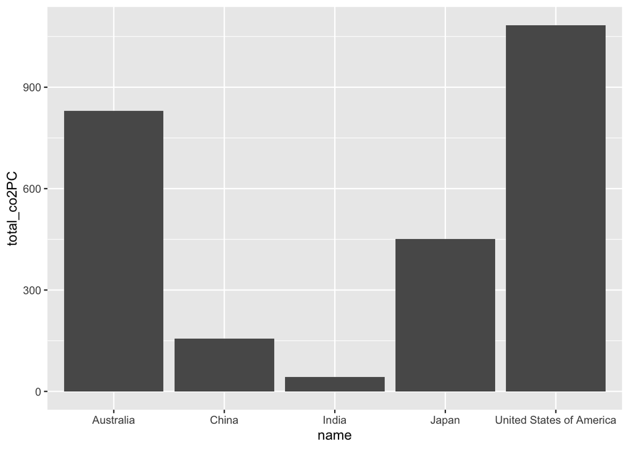

```r
co2PC_plot <- df %>% group_by(name) %>% summarise(total_co2PC = sum(co2_PC,na.rm=TRUE)) %>% filter(name == "United States of America" | name =="China" | name == "India" | name == "Japan" | name == "Australia")

ggplot(data = co2PC_plot, aes(y = total_co2PC, x = name ))+ geom_bar(stat="identity")
```

US has the most total CO2 emissions per capita, but this time Australia has the second most, then is Japan, China, and India. Since now CO2 is caculated by per capita, it make sense that country has larger population has less CO2 emissions per capita.

4. (6pt) Compute average CO2 emissions per capita across the continents (assume region is the same as continent). Comment what do you see. Note: just compute averages over countries and ignore the fact that countries are of different size. Hint: Americas 2016 should be 4.80.

```r
df_region <- df  %>% group_by(region, time) %>% summarise(avg_co2PC = mean(co2_PC, na.rm=TRUE))
df_region %>% arrange(desc(avg_co2PC))
```

```
## # A tibble: 366 × 3
## # Groups:   region [6]
##    region      time avg_co2PC
##    <chr>      <int>     <dbl>
##  1 ""          2015      22.6
##  2 ""          2012      21.9
##  3 ""          2014      20.9
##  4 ""          2016      19.4
##  5 ""          2013      19.2
##  6 "Americas"  1976      13.1
##  7 "Americas"  1973      10.8
##  8 "Americas"  1970      10.3
##  9 "Americas"  1985      10.2
## 10 "Americas"  1974      10.1
## # … with 356 more rows
```

```r
df_region %>% filter(region == "Americas" & time == "2016") # check if match the hint
```

```
## # A tibble: 1 × 3
## # Groups:   region [1]
##   region    time avg_co2PC
##   <chr>    <int>     <dbl>
## 1 Americas  2016      4.80
```

Ignoring the blank regions, Americas seems keep the CO2 emissions per capita in a high level, then is Europe and Asia.

5. (7pt) Make a barplot where you show the previous results–average CO2 emissions per capita across continents in 1960 and 2016.

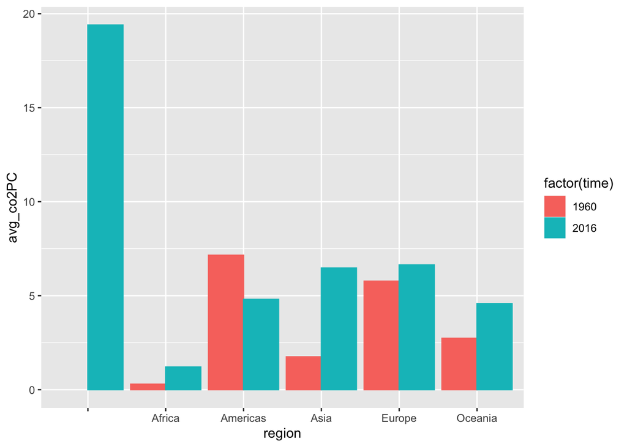

```r
df_region_1960_2016 <- df_region %>% filter(time == "1960" | time == "2016")
ggplot(data = df_region_1960_2016, aes(x = region, y = avg_co2PC, fill = factor(time), colour = factor(time))) + geom_bar(stat="identity",position = "dodge")
```

6. Which countries are the three largest, and three smallest CO2 emitters (in terms of CO2 percapita) in 2019 for each continent? (Assume region is continent).

```r
df %>% filter(time == "2019" & !is.na(co2_PC)) %>% arrange(desc(co2_PC))
```

```
##  [1] iso3                name                iso2
##  [4] region              sub.region          intermediate.region
##  [7] time                totalPopulation     fertilityRate
## [10] lifeExpectancy      childMortality      youthFemaleLiteracy
## [13] youthMaleLiteracy   adultLiteracy       GDP_PC
## [16] accessElectricity   agriculturalLand    agricultureTractors
## [19] cerealProduction    fertilizerHa        co2
## [22] greenhouseGases     co2_PC              pm2.5_35
## [25] battleDeaths
## <0 行> (或0-长度的row.names)
```

I got all NA for filtering 2019. after remove the NA co2_PC, there is nothing left. I saw the conversation in Discord, it seems that I am not the only one with this problem. Otto said that it was fine to use the year 2016 instead as long as I explained. This chunk is to show that year 2019 does not work at all, and the next chunk will use year 2016.

```r
df %>% filter(time == "2016" & !is.na(co2_PC) & region == "Americas") %>% arrange(desc(co2_PC)) %>% head(3)
```

```
##   iso3                     name iso2   region                      sub.region
## 1  TTO      Trinidad and Tobago   TT Americas Latin America and the Caribbean
## 2  USA United States of America   US Americas                Northern America
## 3  CAN                   Canada   CA Americas                Northern America
##   intermediate.region time totalPopulation fertilityRate lifeExpectancy
## 1           Caribbean 2016         1377564        1.7530       73.10000
## 2                     2016       322941311        1.8205       78.53902
## 3                     2016        36109487        1.5433       81.90000
##   childMortality youthFemaleLiteracy youthMaleLiteracy adultLiteracy   GDP_PC
## 1           19.1                  NA                NA            NA 15696.90
## 2            6.7                  NA                NA            NA 52643.92
## 3            5.2                  NA                NA            NA 50193.75
##   accessElectricity agriculturalLand agricultureTractors cerealProduction
## 1               100              540                  NA             4850
## 2               100          4052646                  NA        503465267
## 3               100           580500                  NA         58904067
##   fertilizerHa        co2 greenhouseGases   co2_PC pm2.5_35 battleDeaths
## 1    364.00000   43868.32              NA 31.84485  0.00000           NA
## 2    129.30976 5006302.08              NA 15.50220  0.01645           NA
## 3     99.27329  544894.20              NA 15.09006  0.00000           NA
```

```r
df %>% filter(time == "2016" & !is.na(co2_PC) & region == "Americas") %>% arrange(co2_PC) %>% head(3)
```

```
##   iso3      name iso2   region                      sub.region
## 1  HTI     Haiti   HT Americas Latin America and the Caribbean
## 2  NIC Nicaragua   NI Americas Latin America and the Caribbean
## 3  HND  Honduras   HN Americas Latin America and the Caribbean
##   intermediate.region time totalPopulation fertilityRate lifeExpectancy
## 1           Caribbean 2016        10839970         3.041         62.896
## 2     Central America 2016         6303974         2.455         73.860
## 3     Central America 2016         9270795         2.536         74.701
##   childMortality youthFemaleLiteracy youthMaleLiteracy adultLiteracy   GDP_PC
## 1           68.5            82.63483          83.35350      61.69135 1265.229
## 2           18.7                  NA                NA            NA 1895.200
## 3           18.6            97.24561          94.94519      88.98748 2111.193
##   accessElectricity agriculturalLand agricultureTractors cerealProduction
## 1          40.40000            18400                  NA           523386
## 2          84.74319            50650                  NA           933034
## 3          91.60000            33200                  NA           701829
##   fertilizerHa      co2 greenhouseGases  co2_PC pm2.5_35 battleDeaths
## 1           NA 2977.604              NA 0.27469        0           NA
## 2     59.17761 5592.175              NA 0.88709        0           NA
## 3    164.13011 9812.892              NA 1.05847        0           NA
```

```r
df %>% filter(time == "2016" & !is.na(co2_PC) & region == "Asia") %>% arrange(desc(co2_PC)) %>% head(3)
```

```
##   iso3    name iso2 region   sub.region intermediate.region time
## 1  QAT   Qatar   QA   Asia Western Asia                     2016
## 2  KWT  Kuwait   KW   Asia Western Asia                     2016
## 3  BHR Bahrain   BH   Asia Western Asia                     2016
##   totalPopulation fertilityRate lifeExpectancy childMortality
## 1         2654374         1.907         79.868            7.5
## 2         3956875         2.082         75.224            8.5
## 3         1425791         2.033         76.899            7.4
##   youthFemaleLiteracy youthMaleLiteracy adultLiteracy   GDP_PC
## 1            97.26477          94.80638      93.14530 67187.81
## 2                  NA                NA            NA 35886.99
## 3            98.85029          99.95573      97.06668 22272.97
##   accessElectricity agriculturalLand agricultureTractors cerealProduction
## 1               100              670                  NA             1377
## 2               100             1500                  NA             5257
## 3               100               86                  NA               NA
##   fertilizerHa       co2 greenhouseGases   co2_PC  pm2.5_35 battleDeaths
## 1     216.7832 103259.05              NA 38.90147 100.00000           NA
## 2    1000.7237  98733.98              NA 24.95251  99.89977           NA
## 3     458.8813  31693.88              NA 22.22898 100.00000           NA
```

```r
df %>% filter(time == "2016" & !is.na(co2_PC) & region == "Asia") %>% arrange(co2_PC) %>% head(3)
```

```
##   iso3        name iso2 region    sub.region intermediate.region time
## 1  AFG Afghanistan   AF   Asia Southern Asia                     2016
## 2  NPL       Nepal   NP   Asia Southern Asia                     2016
## 3  YEM       Yemen   YE   Asia  Western Asia                     2016
##   totalPopulation fertilityRate lifeExpectancy childMortality
## 1        35383128         4.800         63.763           67.6
## 2        27261131         2.027         69.848           34.6
## 3        27168210         3.994         66.087           56.8
##   youthFemaleLiteracy youthMaleLiteracy adultLiteracy   GDP_PC
## 1                  NA                NA            NA 571.0738
## 2                  NA                NA            NA 729.6614
## 3                  NA                NA            NA 694.1524
##   accessElectricity agriculturalLand agricultureTractors cerealProduction
## 1          97.70000           379100                  NA          5537315
## 2          90.70000            41210                  NA          8614283
## 3          68.91871           233858                  NA           357068
##   fertilizerHa       co2 greenhouseGases  co2_PC  pm2.5_35 battleDeaths
## 1     13.68015  8672.455              NA 0.24510  99.63784        17978
## 2     74.68117  9105.161              NA 0.33400  99.95669           NA
## 3     18.98242 10608.631              NA 0.39048 100.00000         2846
```

```r
df %>% filter(time == "2016" & !is.na(co2_PC) & region == "Europe") %>% arrange(desc(co2_PC)) %>% head(3)
```

```
##   iso3          name iso2 region      sub.region intermediate.region time
## 1  GIB     Gibraltar   GI Europe Southern Europe                     2016
## 2  LUX    Luxembourg   LU Europe  Western Europe                     2016
## 3  FRO Faroe Islands   FO Europe Northern Europe                     2016
##   totalPopulation fertilityRate lifeExpectancy childMortality
## 1           33737            NA             NA             NA
## 2          582014          1.41       82.68537            2.9
## 3           48173          2.60       82.04390             NA
##   youthFemaleLiteracy youthMaleLiteracy adultLiteracy   GDP_PC
## 1                  NA                NA            NA       NA
## 2                  NA                NA            NA 110162.1
## 3                  NA                NA            NA       NA
##   accessElectricity agriculturalLand agricultureTractors cerealProduction
## 1               100               NA                  NA               NA
## 2               100          1306.51                  NA           139262
## 3               100            30.00                  NA               NA
##   fertilizerHa      co2 greenhouseGases   co2_PC pm2.5_35 battleDeaths
## 1           NA  634.391              NA 18.80401       NA           NA
## 2      262.108 8987.817              NA 15.44261        0           NA
## 3           NA  630.724              NA 13.09289       NA           NA
```

```r
df %>% filter(time == "2016" & !is.na(co2_PC) & region == "Europe") %>% arrange(co2_PC) %>% head(3)
```

```
##   iso3                 name iso2 region      sub.region intermediate.region
## 1  LIE        Liechtenstein   LI Europe  Western Europe
## 2  ALB              Albania   AL Europe Southern Europe
## 3  MDA Moldova, Republic of   MD Europe  Eastern Europe
##   time totalPopulation fertilityRate lifeExpectancy childMortality
## 1 2016           37658         1.610       82.25854             NA
## 2 2016         2876101         1.659       78.19400            9.4
## 3 2016         2802170         1.259       71.61700           15.3
##   youthFemaleLiteracy youthMaleLiteracy adultLiteracy   GDP_PC
## 1                  NA                NA            NA       NA
## 2                  NA                NA            NA 4681.827
## 3                  NA                NA            NA 3119.563
##   accessElectricity agriculturalLand agricultureTractors cerealProduction
## 1            100.00             51.6                  NA               NA
## 2             99.89          11817.0                  NA           698430
## 3            100.00          23179.0                  NA          2954175
##   fertilizerHa      co2 greenhouseGases  co2_PC pm2.5_35 battleDeaths
## 1           NA   51.338              NA 1.36327       NA           NA
## 2    126.13848 4536.079              NA 1.57716        0           NA
## 3     41.91925 5115.465              NA 1.82554        0           NA
```

```r
df %>% filter(time == "2016" & !is.na(co2_PC) & region == "Africa") %>% arrange(desc(co2_PC)) %>% head(3)
```

```
##   iso3         name iso2 region         sub.region intermediate.region time
## 1  ZAF South Africa   ZA Africa Sub-Saharan Africa     Southern Africa 2016
## 2  LBY        Libya   LY Africa    Northern Africa                     2016
## 3  SYC   Seychelles   SC Africa Sub-Saharan Africa      Eastern Africa 2016
##   totalPopulation fertilityRate lifeExpectancy childMortality
## 1        56207649         2.457       63.15300           36.2
## 2         6492164         2.317       72.31100           12.8
## 3           94677         2.390       74.30976           14.8
##   youthFemaleLiteracy youthMaleLiteracy adultLiteracy    GDP_PC
## 1                  NA                NA            NA  7476.090
## 2                  NA                NA            NA  5669.734
## 3                  NA                NA            NA 13606.091
##   accessElectricity agriculturalLand agricultureTractors cerealProduction
## 1          84.20000         963410.0                  NA         10197534
## 2          71.91355         153500.0                  NA           268282
## 3         100.00000             15.5                  NA               NA
##   fertilizerHa        co2 greenhouseGases  co2_PC  pm2.5_35 battleDeaths
## 1     57.25000 476643.994              NA 8.48006   6.15842           NA
## 2     15.58269  50564.263              NA 7.78851 100.00000         1727
## 3    521.73333    605.055              NA 6.39073   0.00000           NA
```

```r
df %>% filter(time == "2016" & !is.na(co2_PC) & region == "Africa") %>% arrange(co2_PC) %>% head(3)
```

```
##   iso3                              name iso2 region         sub.region
## 1  COD Congo, Democratic Republic of the   CD Africa Sub-Saharan Africa
## 2  SOM                           Somalia   SO Africa Sub-Saharan Africa
## 3  BDI                           Burundi   BI Africa Sub-Saharan Africa
##   intermediate.region time totalPopulation fertilityRate lifeExpectancy
## 1       Middle Africa 2016        78789127         6.112         59.655
## 2      Eastern Africa 2016        14185613         6.265         56.324
## 3      Eastern Africa 2016        10487998         5.599         60.528
##   childMortality youthFemaleLiteracy youthMaleLiteracy adultLiteracy   GDP_PC
## 1           93.9            79.71484          90.96097      77.04268 407.2896
## 2          128.4                  NA                NA            NA       NA
## 3           64.1                  NA                NA            NA 219.9615
##   accessElectricity agriculturalLand agricultureTractors cerealProduction
## 1          17.20158           320000                  NA          3032139
## 2          30.87970           441250                  NA           142362
## 3           9.25180            20330                  NA           467773
##   fertilizerHa      co2 greenhouseGases  co2_PC  pm2.5_35 battleDeaths
## 1      1.43182 2020.517              NA 0.02564  89.63482          755
## 2           NA  645.392              NA 0.04550  19.67555         1925
## 3     14.41631  495.045              NA 0.04720 100.00000           NA
```

```r
df %>% filter(time == "2016" & !is.na(co2_PC) & region == "Oceania") %>% arrange(desc(co2_PC)) %>% head(3)
```

```
##   iso3          name iso2  region                sub.region intermediate.region
## 1  NCL New Caledonia   NC Oceania                 Melanesia
## 2  AUS     Australia   AU Oceania Australia and New Zealand
## 3  PLW         Palau   PW Oceania                Micronesia
##   time totalPopulation fertilityRate lifeExpectancy childMortality
## 1 2016          276550         2.080       76.93171             NA
## 2 2016        24190907         1.752       82.44878            3.8
## 3 2016           17725            NA             NA           19.1
##   youthFemaleLiteracy youthMaleLiteracy adultLiteracy   GDP_PC
## 1                  NA                NA            NA       NA
## 2                  NA                NA            NA 55728.68
## 3                  NA                NA            NA 12555.73
##   accessElectricity agriculturalLand agricultureTractors cerealProduction
## 1               100           1840.3                  NA             8817
## 2               100        3426020.0                  NA         35229204
## 3               100             43.0                  NA               NA
##   fertilizerHa        co2 greenhouseGases   co2_PC pm2.5_35 battleDeaths
## 1    248.91122   5328.151              NA 19.26650       NA           NA
## 2     89.08681 375907.837              NA 15.53922        0           NA
## 3           NA    223.687              NA 12.61986       NA           NA
```

```r
df %>% filter(time == "2016" & !is.na(co2_PC) & region == "Oceania") %>% arrange(co2_PC) %>% head(3)
```

```
##   iso3            name iso2  region sub.region intermediate.region time
## 1  SLB Solomon Islands   SB Oceania  Melanesia                     2016
## 2  VUT         Vanuatu   VU Oceania  Melanesia                     2016
## 3  KIR        Kiribati   KI Oceania Micronesia                     2016
##   totalPopulation fertilityRate lifeExpectancy childMortality
## 1          619437         4.452         72.424           21.6
## 2          278330         3.859         70.021           28.0
## 3          112524         3.651         67.577           55.8
##   youthFemaleLiteracy youthMaleLiteracy adultLiteracy   GDP_PC
## 1                  NA                NA            NA 1707.228
## 2                  NA                NA            NA 2803.765
## 3                  NA                NA            NA 1773.028
##   accessElectricity agriculturalLand agricultureTractors cerealProduction
## 1          58.48770             1140                  NA             2726
## 2          57.82000             1870                  NA              897
## 3          93.63701              340                  NA               NA
##   fertilizerHa     co2 greenhouseGases  co2_PC pm2.5_35 battleDeaths
## 1           NA 168.682              NA 0.27232        0           NA
## 2           NA 146.680              NA 0.52700        0           NA
## 3           NA  66.006              NA 0.58659        0           NA
```

- Three largest CO2 emitters in Americas are Trinidad and Tobago, United States of America, and Canada.
- Three smallest CO2 emitters in Americas are Haiti, Nicaragua, and Honduras
- Three largest CO2 emitters in Asia are Qatar, Kuwait, and Bahrain
- Three smallest CO2 emitters in Asia are Afghanistan, Nepal,and Yemen
- Three largest CO2 emitters in Europe are Gibraltar, Luxembourg, and Faroe Islands
- Three smallest CO2 emitters in Europe are Liechtenstein, Albania, and Moldova
- Three largest CO2 emitters in Africa are South Africa, Libya, and Seychelles
- Three smallest CO2 emitters in Africa are Congo, Somalia,and Burundi
- Three largest CO2 emitters in Oceania are New Caledonia, Australia, and Palau
- Three smallest CO2 emitters in Oceania are Solomon Islands, Vanuatu, and Kiribati

**4 GDP per capita (50pt)** Let’s look at GDP per capita (GDP_PC ). 1. (8pt) Make a scatterplot of GDP per capita versus life expectancy by country, using data for 1960. Make the point size dependent on the country size, and color those according to the continent. Feel free to adjust the plot in other ways to make it better. Comment what do you see there.

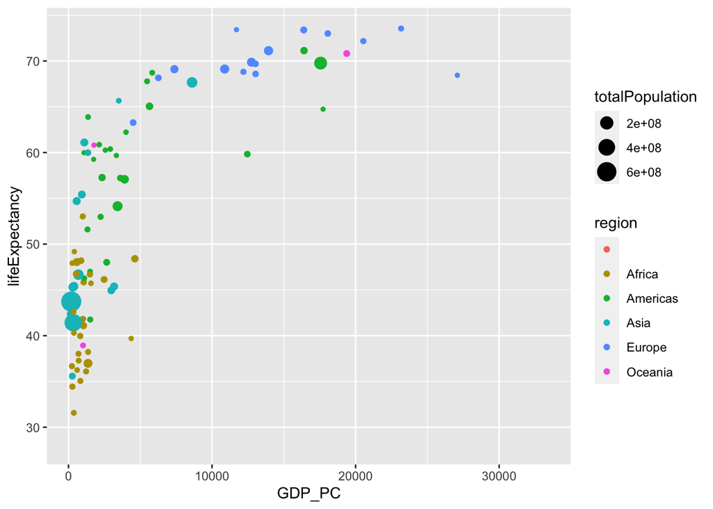

```r
df %>% filter(time == "1960") %>% ggplot(aes(x = GDP_PC, y = lifeExpectancy, size = totalPopulation, col= region)) + geom_point()
```

European countries keep high GDP per capita and life expectancy on the same time, some American countries are on their way. Most African and Asian countries have low GDP per capita and low life expectancy. The plot suggests a positive relationship between GDP per capita and life expectancy.

2. (4pt) Make a similar plot, but this time use 2019 data only.

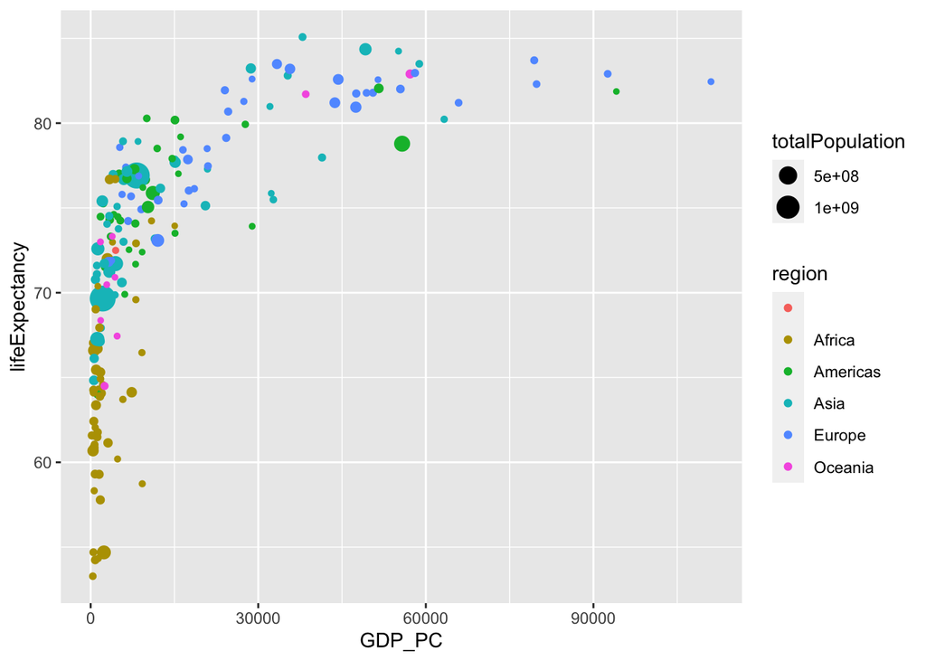

```r
df %>% filter(time == "2019") %>% ggplot(aes(x = GDP_PC, y = lifeExpectancy, size = totalPopulation, col= region)) + geom_point()
```

3. (6pt) Compare these two plots and comment what do you see. How has world developed through the last 60 years?

4. (6pt) Compute the average life expectancy for each continent in 1960 and 2019. Do the results fit with what do you see on the figures? Note: here as average I mean just average over countries, ignore the fact that countries are of different size.

```r
df %>% filter(time == "1960" | time == "2019") %>% group_by(region, time) %>% summarise(avgGDP_PC = mean(GDP_PC, na.rm = TRUE), avglifeExpectancy = mean(lifeExpectancy, na.rm = TRUE))
```

```
## # A tibble: 12 × 4
## # Groups:   region [6]
##    region      time avgGDP_PC avglifeExpectancy
##    <chr>      <int>     <dbl>             <dbl>
##  1 ""          1960      NaN               70.7
##  2 ""          2019     4476.              77.8
##  3 "Africa"    1960     1155.              41.5
##  4 "Africa"    2019     2766.              64.1
##  5 "Americas"  1960     5705.              58.6
##  6 "Americas"  2019    14517.              75.8
##  7 "Asia"      1960     2082.              51.6
##  8 "Asia"      2019    14116.              74.6
##  9 "Europe"    1960    14058.              68.3
## 10 "Europe"    2019    33228.              79.4
## 11 "Oceania"   1960     7388.              56.4
## 12 "Oceania"   2019    11818.              73.5
```

Yes, the results fit with what I see on the figures. All continent improve their average GDP per capita and life expectancy, especially Asia.

5. (8pt) Compute the average LE growth from 1960-2019 across the continents. Show the results in the order of growth. Explain what do you see. Hint: these data (data in long form) is not the simplest to compute growth. But you may want to check out the lag() function. And do not forget to group data by continent when using lag(), otherwise your results will be messed up! See https://faculty.washington. edu/otoomet/info201-book/dplyr.html#dplyr-helpers-compute.

```r
df %>% group_by(region, time) %>% summarise(avgLE = mean(lifeExpectancy, na.rm = TRUE)) %>% mutate(prevLE = lag(avgLE), growth = avgLE - prevLE)
```

```
## # A tibble: 366 × 5
## # Groups:   region [6]
##    region  time avgLE prevLE  growth
##    <chr>  <int> <dbl>  <dbl>   <dbl>
##  1 ""      1960  70.7   NA   NA
##  2 ""      1961  70.8   70.7  0.0940
##  3 ""      1962  70.9   70.8  0.0950
##  4 ""      1963  71.0   70.9  0.102
##  5 ""      1964  71.1   71.0  0.113
##  6 ""      1965  71.3   71.1  0.122
##  7 ""      1966  71.4   71.3  0.126
##  8 ""      1967  71.5   71.4  0.121
##  9 ""      1968  71.6   71.5  0.111
## 10 ""      1969  71.7   71.6  0.103
## # … with 356 more rows
```

6. (6pt) Show the histogram of GDP per capita for years of 1960 and 2019. Try to put both histograms on the same graph, see how well you can do it!

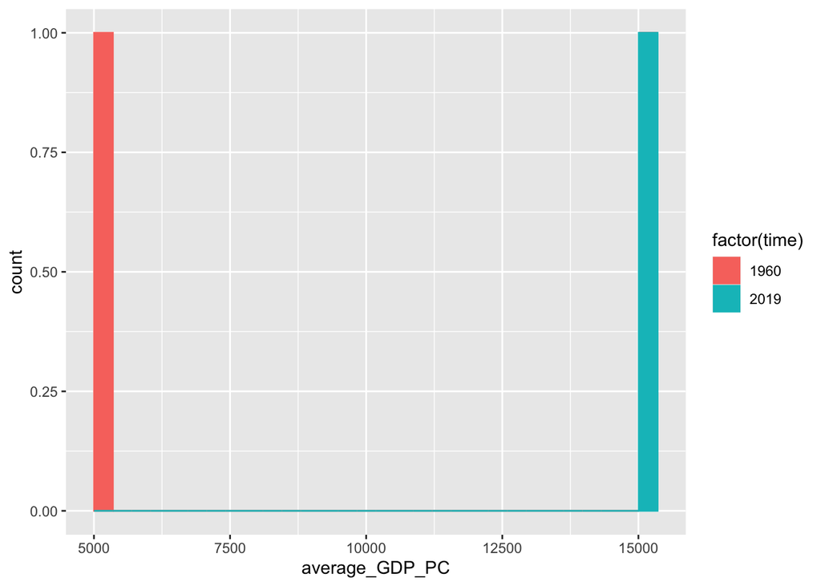

```r
df %>% filter(time == "1960" | time == "2019") %>% group_by(time) %>% summarise(average_GDP_PC = mean(GDP_PC, na.rm = TRUE)) %>% ggplot(aes(x = average_GDP_PC, fill = factor(time), col = factor(time) )) + geom_histogram()
```

Here I assume that the question is asking for the year’s average GDP per capita for 1960 and 2019.

7. (6pt) What was the ranking of US in terms of life expectancy in 1960 and in 2019? (When counting from top.)

Hint: check out the function rank()! Hint2: 17 for 1960.

```r
df %>%  filter(time == "1960" & name != "") %>% mutate(rank = rank(-lifeExpectancy) ) %>% filter (name == "United States of America")
```

```
##   iso3                     name iso2   region       sub.region
## 1  USA United States of America   US Americas Northern America
##   intermediate.region time totalPopulation fertilityRate lifeExpectancy
## 1                     1960       180671000         3.654       69.77073
##   childMortality youthFemaleLiteracy youthMaleLiteracy adultLiteracy   GDP_PC
## 1           30.1                  NA                NA            NA 17562.67
##   accessElectricity agriculturalLand agricultureTractors cerealProduction
## 1                NA               NA                  NA               NA
##   fertilizerHa     co2 greenhouseGases   co2_PC pm2.5_35 battleDeaths rank
## 1           NA 2890696              NA 15.99978       NA           NA   17
```

```r
df %>%  filter(time == "2019"& name != "") %>% mutate(rank = rank(-lifeExpectancy) ) %>% filter (name == "United States of America")
```

```
##   iso3                     name iso2   region       sub.region
## 1  USA United States of America   US Americas Northern America
##   intermediate.region time totalPopulation fertilityRate lifeExpectancy
## 1                     2019       328239523         1.705        78.7878
##   childMortality youthFemaleLiteracy youthMaleLiteracy adultLiteracy   GDP_PC
## 1            6.5                  NA                NA            NA 55753.14
##   accessElectricity agriculturalLand agricultureTractors cerealProduction
## 1               100               NA                  NA               NA
##   fertilizerHa co2 greenhouseGases co2_PC pm2.5_35 battleDeaths rank
## 1           NA  NA              NA     NA       NA           NA   46
```

8. (6pt) If you did this correctly, then you noticed that US ranking has been falling quite a bit. But we also have more countries in 2019–what about the relative rank divided by the corresponding number of countries that have LE data in the corresponding year? Hint: 0.0904 for 1960.

```r
df_1960rank <- df %>%  filter(time == "1960" & name != "" & !is.na(lifeExpectancy)) %>% mutate(rank = rank(-lifeExpectancy) )
df_1960rank[df_1960rank$name == "United States of America", "rank"]/ n_distinct(df_1960rank$name)
```

```
## [1] 0.09042553
```

```r
df_2019rank <- df %>%  filter(time == "2019" & name != "" & !is.na(lifeExpectancy)) %>% mutate(rank = rank(-lifeExpectancy) )
df_2019rank[df_2019rank$name == "United States of America", "rank"]/ n_distinct(df_2019rank$name)
```

```
## [1] 0.2346939
```

**Finally** tell us how many hours did you spend on this PS.

I spend 6-7 hours on this PS. The hardest part is to understand what the question is asking…